# [Last 2000909, Final 191205-1212, 18project, 3T3] BRBseq0432lane2_QC_tmpl_v6_noumi_H3mm18_Dox_linear_0718_fin191205_last200811_add200910 (umi補正なし,fdr0.1) (TPM,尤度比検定)

### Setup

```r
library(ggplot2)
library(dplyr)
library(tidyr)
library(purrr)
source("/home/guestA/n70275b/work/rscripts/geomNorm.R")

# Helper function
#ggpoints <- function(x,...)
#  ggplot(x,...) + geom_point(size=3,stroke=1) +
#  ggrepel::geom_text_repel(size=4) + theme_minimal() + mycolor

## ラベルあり
ggpoints <- function(x,...)
  ggplot(x,...) + geom_point(stroke=1) +
  ggrepel::geom_text_repel(size=4) + theme_minimal() + mycolor

## ラベルなし
#ggpoints <- function(x,...)
#  ggplot(x,...) + geom_point(stroke=1) + theme_minimal() + mycolor
```

```r
select <- dplyr::select
count <- dplyr::count
rename <- dplyr::rename
```

### Parameters

*modify here*

```r
# Files


#deftable <- "~/akuwakado/kuwakado/BRBSeq/H3mm18_Dox_0432lane2/Final_Rserver_191203/deftable_BRB_noumi_new_190520_fin191205ver.txt" #Umi補正なし (BRB)

deftable <- "/home/guestA/o70578a/akuwakado/kuwakado/BRBSeq/H3mm18_Dox_0432lane2/Final_Last_Rserver_200811/deftable_BRB_noumi_new_190520_Last20200811ver.txt"

#deftable <- "~/akuwakado/kuwakado/BRBSeq/H3mm18_Dox_0432lane2/Final_Rserver_191203/deftable_BRB_noumi_new_190520_fin191205ver.txt" #Umi補正なし (BRB)


#deftable <- "deftable_BRB_noumi_new_190520.txt" #Umi補正なし (BRB)

#deftable <- "~/akuwakado/kuwakado/BRBSeq/H3mm18_Dox_0432lane2/deftable_BRB_noumi_new_190520.txt" #Umi補正なし (BRB)


## Data selection (filter rows of deftable)
#use <- quo(!grepl("^18",group) & (group != "Nc-minusTryd"))
#use <- quo(TRUE) # use all
use <- quo(type != "C2C12")

# Species specific parameters
species <- "Mus musculus"
biomartann <- "mmusculus_gene_ensembl"
maxchrom <- 19 # 19: mouse, 22: human


# Graphics
# aesthetic mapping of labels
#myaes <- aes(colour=enzyme,shape=leg,label=rep)
#myaes <- aes(colour=growth,shape=type,size=count) #ラベルなし
#myaes <- aes(colour=growth,shape=type,label=replicate,size=count) #ラベルあり
#myaes <- aes(colour=enzyme,shape=leg,label=replicate) #ラベルあり
#myaes <- aes(colour=enzyme,shape=leg,label=factor(rep))
#myaes <- aes(colour=type, shape=revcro, label=read, size=count)
#myaes <- aes(colour=type, shape=revcro, label=read)

#myaes <- aes(colour=growth,shape=type,label=replicate,size=count) #ラベルあり
#myaes <- aes(colour=time,shape=type,size=count,label=replicate)
#myaes <- aes(colour=WT_KO_intact_CTX, shape=Day,size=count,label=f_m)

#myaes <- aes(colour=WT_KO_intact_CTX, shape=Day, label=f_m) #サイズを変えず
#myaes <- aes(colour=growth,shape=type,label=replicate,size=count) #ラベルあり
myaes <- aes(colour=time,shape=type,label=rep,size=count) #ラベルあり
myaes2 <- aes(colour=time,shape=type) #kuwa add

# color palette of points: See vignette("ggsci")
mycolor <- ggsci::scale_color_aaas()



# PCA/UMAP
scalerows <- TRUE # gene-wise scaling (pattern is the matter?)
ntop <- 500 # number of top-n genes with high variance
seed <- 123 # set another number if UMAP looks not good
n_nei <- 6  # number of neighboring data points in UMAP #ここをどうしたらいい？


# DESeq2
#model <- ~groupn+lead #dateも追加
#model <- ~leg + enzyme + leg:enzyme
#model <- ~type+growth#+type:growth
#model <- ~group+lead


#model <- ~group
#model <- ~type+growth+type:growth #これでは相互作用が入っていない
#model <- ~type+growth #これでは相互作用が入っていない


model <- ~group
#model <- ~type+growth+growth:type

fdr <- 0.1 # acceptable false discovery rate
lfcthreth <- log2(1) # threshold in abs(log2FC)

# controls should be placed in the right
contrast <- list(

  group_UI_Doxplus_vs_minus = c("group", "BRB_UI_DoxPlus", "BRB_UI_DoxMinus"),
  group_0h_Doxplus_vs_minus = c("group", "BRB_0h_DoxPlus", "BRB_0h_DoxMinus"),
  group_24h_Doxplus_vs_minus = c("group", "BRB_24h_DoxPlus", "BRB_24h_DoxMinus"),
  group_48h_Doxplus_vs_minus = c("group", "BRB_48h_DoxPlus", "BRB_48h_DoxMinus")


  #group_UI_Doxplus_vs_minus = c("group", "Doxplus_UI", "Doxminus_UI"),
  #group_Diff0h_Doxplus_vs_minus = c("group", "Doxplus_Diff0h", "Doxminus_Diff0h"),
  #group_Diff24h_Doxplus_vs_minus = c("group", "Doxplus_Diff24h", "Doxminus_Diff24h"),
  #group_Diff48h_Doxplus_vs_minus = c("group", "Doxplus_Diff48h", "Doxminus_Diff48h")


  #Intercept = list("Intercept"), # reference level
  #leg_LvsR = c("leg", "L", "R"),
  #enz_KvsC = c("enzyme","K","C")
  #legL.enzK = list("legL.enzymeK") # interaction

  #type_Doxplus_vs_minus = c("type", "Doxplus", "Doxminus")
)
```

### Retrieve Biomart

```r
#if(!exists("e2g")){
#  #ensembl <- biomaRt::useMart("ENSEMBL_MART_ENSEMBL",host="asia.ensembl.org")
#  #ensembl <- biomaRt::useMart("ENSEMBL_MART_ENSEMBL",host="uswest.ensembl.org")
#  ensembl <- biomaRt::useMart("ENSEMBL_MART_ENSEMBL",host="useast.ensembl.org")
#  mart <- biomaRt::useDataset(biomartann,mart=ensembl)
#  e2g <- biomaRt::getBM(attributes=c("ensembl_gene_id","external_gene_name",
#    "gene_biotype","chromosome_name"), mart=mart) %>% as_tibble %>%
#  rename(
#    ens_gene = ensembl_gene_id,
#    ext_gene = external_gene_name,
#    biotype = gene_biotype,
#    chr = chromosome_name
#  )
#}

e2g <- readr::read_csv("/home/guestA/o70578a/akuwakado/kuwakado/BRBSeq/H3mm18_Dox_0432lane2/Final_Last_Rserver_200811/ensemble_list_useast.csv")
annotate <- partial(right_join,e2g,by="ens_gene")

#annotate <- partial(right_join,e2g,by="ens_gene")

#-----#
nrow(e2g)
```

```
[1] 56305
```

```r
#readr::write_csv(e2g,"ensemble_list_asia.csv")
#readr::write_csv(e2g,"ensemble_list_uswest.csv")
#readr::write_csv(e2g,"ensemble_list_useast.csv")
```

### Load counts

```r
def <- readr::read_tsv(deftable) %>% filter(!!use)
print(def)
```

| file | sample0 | barcode | growth | sample | group | time | type | seq | rep |
| --- | --- | --- | --- | --- | --- | --- | --- | --- | --- |
| /home/guestA/o70578a/akuwakado/kuwakado/BRBSeq/H3mm18_Dox_0432lane2/Undetermined_L2.counts.txt.gz | Dox-_UI_1 | ATGCATATG | UI | BRB_UI_DoxMinus_1 | BRB_UI_DoxMinus | UI | DoxMinus | BRB | 1 |
| /home/guestA/o70578a/akuwakado/kuwakado/BRBSeq/H3mm18_Dox_0432lane2/Undetermined_L2.counts.txt.gz | Dox-_UI_2 | ATTATGCAA | UI | BRB_UI_DoxMinus_2 | BRB_UI_DoxMinus | UI | DoxMinus | BRB | 2 |
| /home/guestA/o70578a/akuwakado/kuwakado/BRBSeq/H3mm18_Dox_0432lane2/Undetermined_L2.counts.txt.gz | Dox-_UI_3 | ATCGGTTGC | UI | BRB_UI_DoxMinus_3 | BRB_UI_DoxMinus | UI | DoxMinus | BRB | 3 |
| /home/guestA/o70578a/akuwakado/kuwakado/BRBSeq/H3mm18_Dox_0432lane2/Undetermined_L2.counts.txt.gz | Dox-_UI_4 | ACTGCGCGG | UI | BRB_UI_DoxMinus_4 | BRB_UI_DoxMinus | UI | DoxMinus | BRB | 4 |
| /home/guestA/o70578a/akuwakado/kuwakado/BRBSeq/H3mm18_Dox_0432lane2/Undetermined_L2.counts.txt.gz | Dox+_UI_1 | AAGGAGAGT | UI | BRB_UI_DoxPlus_1 | BRB_UI_DoxPlus | UI | DoxPlus | BRB | 1 |
| /home/guestA/o70578a/akuwakado/kuwakado/BRBSeq/H3mm18_Dox_0432lane2/Undetermined_L2.counts.txt.gz | Dox+_UI_2 | AGGAGAGAG | UI | BRB_UI_DoxPlus_2 | BRB_UI_DoxPlus | UI | DoxPlus | BRB | 2 |
| /home/guestA/o70578a/akuwakado/kuwakado/BRBSeq/H3mm18_Dox_0432lane2/Undetermined_L2.counts.txt.gz | Dox+_UI_3 | CAGTCTAGA | UI | BRB_UI_DoxPlus_3 | BRB_UI_DoxPlus | UI | DoxPlus | BRB | 3 |
| /home/guestA/o70578a/akuwakado/kuwakado/BRBSeq/H3mm18_Dox_0432lane2/Undetermined_L2.counts.txt.gz | Dox+_UI_4 | CAACGAGAT | UI | BRB_UI_DoxPlus_4 | BRB_UI_DoxPlus | UI | DoxPlus | BRB | 4 |
| /home/guestA/o70578a/akuwakado/kuwakado/BRBSeq/H3mm18_Dox_0432lane2/Undetermined_L2.counts.txt.gz | Dox-_Diff0h_1 | CTCTATTAA | Diff0h | BRB_0h_DoxMinus_1 | BRB_0h_DoxMinus | 0h | DoxMinus | BRB | 1 |
| /home/guestA/o70578a/akuwakado/kuwakado/BRBSeq/H3mm18_Dox_0432lane2/Undetermined_L2.counts.txt.gz | Dox-_Diff0h_2 | CTGATGACG | Diff0h | BRB_0h_DoxMinus_2 | BRB_0h_DoxMinus | 0h | DoxMinus | BRB | 2 |

[output cut: 22 more lines]

```r
#def$growth <- factor(def$growth,levels =c("UI","Diff0h","Diff24h","Diff48h"))
#def$type <- factor(def$type,levels =c("Doxminus","Doxplus"))

#factor(def$growth,levels =c("UI","Diff0h","Diff24h","Diff48h"))
# [1] UI      UI      UI      UI      UI      UI      UI      UI      Diff0h  Diff0h  Diff0h  Diff0h  Diff0h  Diff0h  Diff0h  Diff0h  Diff24h Diff24h Diff24h Diff24h
#[21] Diff24h Diff24h Diff24h Diff24h Diff48h Diff48h Diff48h Diff48h Diff48h Diff48h Diff48h Diff48h
#Levels: UI Diff0h Diff24h Diff48h


####--- New ---#### (no UMI ?)
# Set reference levels according to the contrast
for(x in keep(contrast,is.character))
  def[[x[1]]] <- relevel(factor(def[[x[1]]]),x[3])

umi <- def$file %>% unique %>% tibble(file=.) %>%
  dplyr::mutate(data=map(file,readr::read_tsv,progress=FALSE)) %>%
  unnest() %>% dplyr::rename(barcode=cell) %>%
  dplyr::inner_join(select(def,file,barcode,sample),.,c("file","barcode")) %>%
  select(-file,-barcode) %>% dplyr::rename(ens_gene=gene)
```

```
`cols` is now required when using unnest().
Please use `cols = c(data)`
```

```r
print(umi)
```

| sample | ens_gene | count |
| --- | --- | --- |
| BRB_UI_DoxMinus_1 | ENSMUSG00000000001 | 71 |
| BRB_UI_DoxMinus_1 | ENSMUSG00000000028 | 51 |
| BRB_UI_DoxMinus_1 | ENSMUSG00000000056 | 12 |
| BRB_UI_DoxMinus_1 | ENSMUSG00000000058 | 59 |
| BRB_UI_DoxMinus_1 | ENSMUSG00000000078 | 77 |
| BRB_UI_DoxMinus_1 | ENSMUSG00000000085 | 40 |
| BRB_UI_DoxMinus_1 | ENSMUSG00000000088 | 46 |
| BRB_UI_DoxMinus_1 | ENSMUSG00000000126 | 4 |
| BRB_UI_DoxMinus_1 | ENSMUSG00000000127 | 22 |
| BRB_UI_DoxMinus_1 | ENSMUSG00000000131 | 27 |

[output cut: 990 more lines]

```r
## sample, barcode, file を忘れずに！

mat <- umi %>% annotate %>%
  dplyr::mutate(chr=factor(chr,c(1:maxchrom,"X","Y","MT"))) %>%
  filter(!is.na(chr)) %>% spread(sample,count,fill=0)

## to check read vias, this add read number as "n" column (2019/4/19)
def <- umi %>% count(sample,wt=count) %>% dplyr::inner_join(def,.) %>% dplyr::rename(count=n)
####-----------####




# Set reference levels according to the contrast
#for(x in keep(contrast,is.character))
#  def[[x[1]]] <- relevel(factor(def[[x[1]]]),x[3])

#umi <- def$file %>% unique %>% tibble(file=.) %>%
#  mutate(data=map(file,readr::read_tsv,progress=FALSE)) %>%
#  unnest() %>% dplyr::rename(barcode=cell) %>%
#  inner_join(select(def,file,barcode,sample),.,c("file","barcode")) %>%
#  select(-file,-barcode) %>% dplyr::rename(ens_gene=gene)

#mat <- umi %>% annotate %>%
#  mutate(chr=factor(chr,c(1:maxchrom,"X","Y","MT"))) %>%
#  filter(!is.na(chr)) %>% spread(sample,count,fill=0)

print(mat)
```

| ens_gene | ext_gene | biotype | chr | BRB_0h_DoxMinus_1 | BRB_0h_DoxMinus_2 | BRB_0h_DoxMinus_3 | BRB_0h_DoxMinus_4 | BRB_0h_DoxPlus_1 | BRB_0h_DoxPlus_2 | BRB_0h_DoxPlus_3 | BRB_0h_DoxPlus_4 | BRB_24h_DoxMinus_1 | BRB_24h_DoxMinus_2 | BRB_24h_DoxMinus_3 | BRB_24h_DoxMinus_4 | BRB_24h_DoxPlus_1 | BRB_24h_DoxPlus_2 | BRB_24h_DoxPlus_3 | BRB_24h_DoxPlus_4 | BRB_48h_DoxMinus_1 | BRB_48h_DoxMinus_2 | BRB_48h_DoxMinus_3 | BRB_48h_DoxMinus_4 | BRB_48h_DoxPlus_1 | BRB_48h_DoxPlus_2 | BRB_48h_DoxPlus_3 | BRB_48h_DoxPlus_4 | BRB_UI_DoxMinus_1 | BRB_UI_DoxMinus_2 | … |
| --- | --- | --- | --- | --- | --- | --- | --- | --- | --- | --- | --- | --- | --- | --- | --- | --- | --- | --- | --- | --- | --- | --- | --- | --- | --- | --- | --- | --- | --- | --- |
| ENSMUSG00000064372 | mt-Tp | Mt_tRNA | MT | 19 | 14 | 2 | 23 | 25 | 10 | 39 | 14 | 25 | 10 | 6 | 9 | 25 | 6 | 36 | 35 | 10 | 19 | 21 | 10 | 5 | 20 | 15 | 1 | 18 | 21 | … |
| ENSMUSG00000064371 | mt-Tt | Mt_tRNA | MT | 3 | 3 | 6 | 5 | 1 | 1 | 10 | 4 | 2 | 5 | 5 | 1 | 5 | 0 | 4 | 4 | 3 | 0 | 0 | 1 | 1 | 4 | 1 | 4 | 11 | 4 | … |
| ENSMUSG00000064370 | mt-Cytb | protein_coding | MT | 7986 | 6543 | 10642 | 23740 | 8829 | 7306 | 8790 | 7303 | 15875 | 19997 | 9736 | 13336 | 17238 | 7711 | 12655 | 15282 | 13409 | 13329 | 14959 | 14670 | 12958 | 14031 | 12835 | 8696 | 7572 | 10236 | … |
| ENSMUSG00000064369 | mt-Te | Mt_tRNA | MT | 15 | 4 | 5 | 36 | 6 | 10 | 10 | 6 | 9 | 17 | 5 | 8 | 17 | 6 | 12 | 27 | 6 | 7 | 6 | 11 | 7 | 8 | 3 | 0 | 6 | 6 | … |
| ENSMUSG00000064368 | mt-Nd6 | protein_coding | MT | 1812 | 1222 | 2515 | 5734 | 1554 | 1451 | 1852 | 1516 | 3095 | 4199 | 1795 | 2122 | 2934 | 1359 | 2023 | 2440 | 2710 | 2372 | 2413 | 2655 | 2252 | 2048 | 1738 | 1211 | 1501 | 1986 | … |
| ENSMUSG00000064367 | mt-Nd5 | protein_coding | MT | 1019 | 640 | 1089 | 2439 | 715 | 734 | 910 | 676 | 1031 | 1174 | 589 | 804 | 906 | 496 | 691 | 808 | 745 | 637 | 856 | 840 | 663 | 788 | 709 | 491 | 856 | 1005 | … |
| ENSMUSG00000064366 | mt-Tl2 | Mt_tRNA | MT | 0 | 0 | 0 | 0 | 0 | 0 | 0 | 0 | 0 | 7 | 0 | 0 | 1 | 0 | 0 | 7 | 0 | 0 | 0 | 0 | 0 | 0 | 0 | 0 | 0 | 0 | … |
| ENSMUSG00000064365 | mt-Ts2 | Mt_tRNA | MT | 0 | 0 | 3 | 0 | 0 | 0 | 0 | 0 | 0 | 0 | 0 | 5 | 0 | 2 | 0 | 2 | 0 | 0 | 1 | 0 | 0 | 0 | 0 | 1 | 0 | 0 | … |
| ENSMUSG00000064364 | mt-Th | Mt_tRNA | MT | 0 | 0 | 0 | 0 | 0 | 0 | 0 | 0 | 0 | 0 | 0 | 0 | 0 | 0 | 0 | 0 | 0 | 0 | 0 | 0 | 0 | 3 | 0 | 0 | 0 | 0 | … |
| ENSMUSG00000064363 | mt-Nd4 | protein_coding | MT | 5292 | 4652 | 8150 | 17484 | 5983 | 4308 | 5923 | 5328 | 11135 | 14725 | 7433 | 9211 | 11742 | 4835 | 8844 | 10592 | 9794 | 10022 | 10619 | 10383 | 8915 | 8798 | 8188 | 5716 | 5104 | 7275 | … |

[output cut: 990 more lines]

```r
## to check read vias, this add read number as "n" column (2019/4/19)
#def <- umi %>% count(sample,wt=count) %>% inner_join(def,.) %>% dplyr::rename(count=n)

print(def)
```

| file | sample0 | barcode | growth | sample | group | time | type | seq | rep | count |
| --- | --- | --- | --- | --- | --- | --- | --- | --- | --- | --- |
| /home/guestA/o70578a/akuwakado/kuwakado/BRBSeq/H3mm18_Dox_0432lane2/Undetermined_L2.counts.txt.gz | Dox-_UI_1 | ATGCATATG | UI | BRB_UI_DoxMinus_1 | BRB_UI_DoxMinus | UI | DoxMinus | BRB | 1 | 699171 |
| /home/guestA/o70578a/akuwakado/kuwakado/BRBSeq/H3mm18_Dox_0432lane2/Undetermined_L2.counts.txt.gz | Dox-_UI_2 | ATTATGCAA | UI | BRB_UI_DoxMinus_2 | BRB_UI_DoxMinus | UI | DoxMinus | BRB | 2 | 871303 |
| /home/guestA/o70578a/akuwakado/kuwakado/BRBSeq/H3mm18_Dox_0432lane2/Undetermined_L2.counts.txt.gz | Dox-_UI_3 | ATCGGTTGC | UI | BRB_UI_DoxMinus_3 | BRB_UI_DoxMinus | UI | DoxMinus | BRB | 3 | 679935 |
| /home/guestA/o70578a/akuwakado/kuwakado/BRBSeq/H3mm18_Dox_0432lane2/Undetermined_L2.counts.txt.gz | Dox-_UI_4 | ACTGCGCGG | UI | BRB_UI_DoxMinus_4 | BRB_UI_DoxMinus | UI | DoxMinus | BRB | 4 | 721034 |
| /home/guestA/o70578a/akuwakado/kuwakado/BRBSeq/H3mm18_Dox_0432lane2/Undetermined_L2.counts.txt.gz | Dox+_UI_1 | AAGGAGAGT | UI | BRB_UI_DoxPlus_1 | BRB_UI_DoxPlus | UI | DoxPlus | BRB | 1 | 742420 |
| /home/guestA/o70578a/akuwakado/kuwakado/BRBSeq/H3mm18_Dox_0432lane2/Undetermined_L2.counts.txt.gz | Dox+_UI_2 | AGGAGAGAG | UI | BRB_UI_DoxPlus_2 | BRB_UI_DoxPlus | UI | DoxPlus | BRB | 2 | 636365 |
| /home/guestA/o70578a/akuwakado/kuwakado/BRBSeq/H3mm18_Dox_0432lane2/Undetermined_L2.counts.txt.gz | Dox+_UI_3 | CAGTCTAGA | UI | BRB_UI_DoxPlus_3 | BRB_UI_DoxPlus | UI | DoxPlus | BRB | 3 | 685029 |
| /home/guestA/o70578a/akuwakado/kuwakado/BRBSeq/H3mm18_Dox_0432lane2/Undetermined_L2.counts.txt.gz | Dox+_UI_4 | CAACGAGAT | UI | BRB_UI_DoxPlus_4 | BRB_UI_DoxPlus | UI | DoxPlus | BRB | 4 | 643096 |
| /home/guestA/o70578a/akuwakado/kuwakado/BRBSeq/H3mm18_Dox_0432lane2/Undetermined_L2.counts.txt.gz | Dox-_Diff0h_1 | CTCTATTAA | Diff0h | BRB_0h_DoxMinus_1 | BRB_0h_DoxMinus | 0h | DoxMinus | BRB | 1 | 706396 |
| /home/guestA/o70578a/akuwakado/kuwakado/BRBSeq/H3mm18_Dox_0432lane2/Undetermined_L2.counts.txt.gz | Dox-_Diff0h_2 | CTGATGACG | Diff0h | BRB_0h_DoxMinus_2 | BRB_0h_DoxMinus | 0h | DoxMinus | BRB | 2 | 599006 |

[output cut: 22 more lines]

```r
##====================================##
# 確認 (20191204) ２つの値は一緒か？
# 生のデータカウント中の遺伝子総数

umi %>% group_by(ens_gene) %>% summarise %>% nrow()
```

```
[1] 21871
```

```r
umi %>% spread(sample,count,fill=0) %>% nrow()
```

```
[1] 21871
```

```r
mat %>% nrow()
```

```
[1] 21742
```

```r
mat %>% filter(chr!="MT") %>% nrow() # MTなし
```

```
[1] 21707
```

```r
# matでは、chr等が不明なものは省いている。
# DEGでは、さらにMTも省いている。
##====================================##
```

### Reads breakdown

#### Total reads

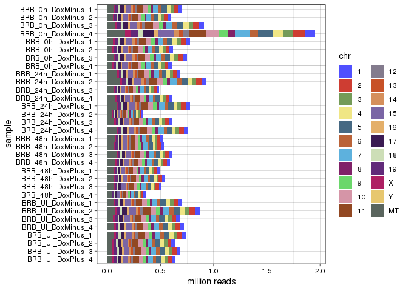

```r
bychr <- mat %>% select(-(1:3)) %>%
  gather("sample","count",-chr) %>%
  group_by(chr,sample) %>% summarise(total=sum(count)) %>% ungroup
ggplot(bychr,aes(reorder(sample,dplyr::desc(sample)),total/1e6,fill=chr)) +
  theme_linedraw() + geom_bar(stat="identity") + coord_flip() +
  xlab("sample") + ylab("million reads") + ggsci::scale_fill_igv() +
  scale_x_discrete(limits = rev(levels(sample)))
```

```r
NA
NA
```

#### Biotype

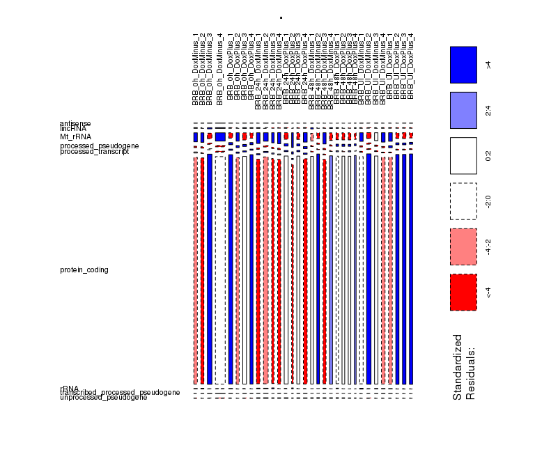

```r
bt <- mat %>% select(-c(1,2,4)) %>% group_by(biotype) %>%
  summarise_all(sum) %>% filter_at(-1,any_vars(. > 1000))
bt %>% tibble::column_to_rownames("biotype") %>%
  as.matrix %>% t %>% mosaicplot(las=2,shade=TRUE)
```

### Correlations

drop rows with all 0 -> +1/2 -> geom.scale -> log -> Pearson’s

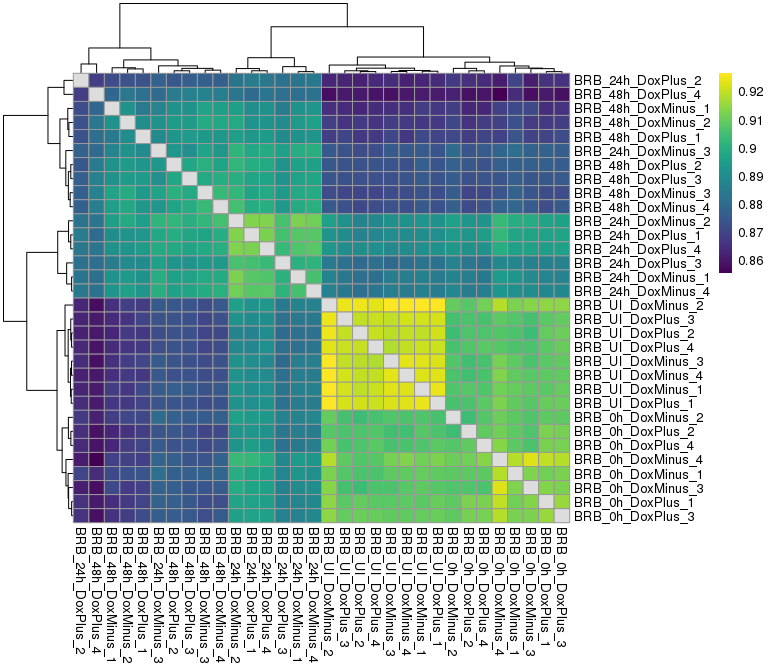

```r
matf <- mat %>% filter(chr!="MT") %>% filter_at(-(1:4),any_vars(. > 0))
X <- matf %>% select(-(1:4)) %>% as.matrix
rownames(X) <- matf$ens_gene
lX <- log(gscale(X+0.5))
R <- cor(lX); diag(R) <- NA
pheatmap::pheatmap(R,color=viridis::viridis(256))
```

### Dimension reduction

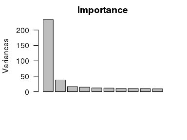

```r
# set scale=TRUE if the patterns (not level) is the matter
p <- prcomp(t(lX[rank(-apply(lX,1,var)) <= ntop,]),scale=scalerows,center=TRUE)
screeplot(p,las=2,main="Importance")
```

```r
print(summary(p)$imp[,seq(min(10,ncol(X)))])
```

```
                            PC1      PC2      PC3      PC4      PC5      PC6      PC7      PC8      PC9     PC10
Standard deviation     15.29237 6.164198 4.042076 3.825442 3.469872 3.401714 3.278207 3.191635 3.138257 3.038142
Proportion of Variance  0.46771 0.075990 0.032680 0.029270 0.024080 0.023140 0.021490 0.020370 0.019700 0.018460
Cumulative Proportion   0.46771 0.543710 0.576380 0.605650 0.629730 0.652880 0.674370 0.694740 0.714440 0.732900
```

```r
label <- def %>% filter(sample %in% colnames(X))
df <- data.frame(p$x) %>% as_tibble(rownames="sample") %>%
  inner_join(label,.) %>% select(-file)
print(df)
```

| sample0 | barcode | growth | sample | group | time | type | seq | rep | count | PC1 | PC2 | PC3 | PC4 | PC5 | PC6 | PC7 | PC8 | PC9 | PC10 | PC11 | PC12 | PC13 | PC14 | PC15 | PC16 | PC17 | PC18 | PC19 | PC20 | … |
| --- | --- | --- | --- | --- | --- | --- | --- | --- | --- | --- | --- | --- | --- | --- | --- | --- | --- | --- | --- | --- | --- | --- | --- | --- | --- | --- | --- | --- | --- | --- |
| Dox-_UI_1 | ATGCATATG | UI | BRB_UI_DoxMinus_1 | BRB_UI_DoxMinus | UI | DoxMinus | BRB | 1 | 699171 | -15.893826 | -6.5441567 | -2.7392642 | 0.07236122 | -1.32307782 | 0.92836550 | 0.6767937 | 4.3136841 | -4.68577952 | -1.38804045 | -1.05069719 | -1.9133907 | -0.704046173 | -2.69470579 | -0.83102204 | 0.5729134 | -3.6710279 | 1.4126079 | 2.5034806 | 1.3044267 | … |
| Dox-_UI_2 | ATTATGCAA | UI | BRB_UI_DoxMinus_2 | BRB_UI_DoxMinus | UI | DoxMinus | BRB | 2 | 871303 | -19.539909 | -5.0440518 | -2.2507800 | -1.54207282 | -0.63251845 | -0.04717445 | -1.9172595 | -0.1893282 | 3.20111443 | 0.45707432 | 2.95925750 | 0.6567654 | 0.158169768 | -0.48903468 | -1.26662554 | 4.6677266 | 3.1430387 | -3.7384635 | -3.4694507 | -0.9424632 | … |
| Dox-_UI_3 | ATCGGTTGC | UI | BRB_UI_DoxMinus_3 | BRB_UI_DoxMinus | UI | DoxMinus | BRB | 3 | 679935 | -16.637778 | -8.4064906 | -2.4960675 | 0.62027675 | -0.81360431 | -0.60277557 | 0.4767009 | 2.4967586 | 2.83676129 | -0.23585528 | 4.52123139 | 1.5564047 | -5.716280062 | -2.45872289 | 1.04427064 | -0.5820445 | 0.5365473 | -1.2575339 | -1.2647577 | -1.4928806 | … |
| Dox-_UI_4 | ACTGCGCGG | UI | BRB_UI_DoxMinus_4 | BRB_UI_DoxMinus | UI | DoxMinus | BRB | 4 | 721034 | -17.070737 | -7.7911616 | -3.7631364 | -0.87625970 | 2.95275012 | 0.27799790 | -0.6249330 | -3.3615105 | 2.48313724 | -0.60041816 | -1.34132954 | -1.8007512 | -0.546779191 | -3.10891134 | 0.45077114 | 1.7646884 | 1.9626723 | -2.7930580 | -1.2413789 | 1.2173268 | … |
| Dox+_UI_1 | AAGGAGAGT | UI | BRB_UI_DoxPlus_1 | BRB_UI_DoxPlus | UI | DoxPlus | BRB | 1 | 742420 | -17.752174 | -8.3240593 | -1.0002048 | 0.03689610 | 0.95366580 | -1.17799884 | 0.7031784 | 0.2817542 | 0.57249236 | 1.55339155 | -3.87756122 | -1.0659764 | 0.962436238 | 5.57178263 | -1.43273907 | 2.8524756 | -1.5142138 | 0.2628295 | 1.0643965 | 3.0303205 | … |
| Dox+_UI_2 | AGGAGAGAG | UI | BRB_UI_DoxPlus_2 | BRB_UI_DoxPlus | UI | DoxPlus | BRB | 2 | 636365 | -15.968829 | -6.6155540 | 1.4899238 | -0.14241061 | 0.90534778 | -1.18993592 | 0.9025543 | -3.1488976 | -0.27008272 | 2.03502131 | -1.99734748 | 2.0671744 | -0.383052642 | 1.04919304 | -1.70672565 | -2.3772663 | -1.9887835 | 2.1756021 | -1.2547395 | -4.4399684 | … |
| Dox+_UI_3 | CAGTCTAGA | UI | BRB_UI_DoxPlus_3 | BRB_UI_DoxPlus | UI | DoxPlus | BRB | 3 | 685029 | -16.369342 | -8.8982130 | -3.6285637 | -2.42151110 | -1.69735611 | 0.79655632 | -1.2214296 | -1.9044876 | -1.49581046 | 1.36641732 | -0.32118821 | 1.4213102 | 2.036647439 | 0.79243998 | 5.12525107 | -1.8299251 | -0.3159377 | 1.3200968 | 2.6509677 | 1.2862477 | … |
| Dox+_UI_4 | CAACGAGAT | UI | BRB_UI_DoxPlus_4 | BRB_UI_DoxPlus | UI | DoxPlus | BRB | 4 | 643096 | -16.178898 | -6.5802951 | 1.8374935 | -2.55606770 | -0.95924417 | 0.64095898 | 2.5122553 | 0.5571177 | -6.98950915 | -1.23001608 | 1.00937240 | -0.1433244 | 2.810531691 | 0.67029430 | -1.69011191 | -3.3503401 | 1.7177430 | 2.8747555 | 1.0714652 | -2.2960849 | … |
| Dox-_Diff0h_1 | CTCTATTAA | Diff0h | BRB_0h_DoxMinus_1 | BRB_0h_DoxMinus | 0h | DoxMinus | BRB | 1 | 706396 | -10.754033 | 6.7764489 | -0.8230746 | 2.89014424 | -0.33744840 | 0.32911375 | -0.5050229 | 2.9398034 | 1.41659711 | -3.49964743 | 0.04036880 | 3.2554100 | 1.309766950 | 1.19018947 | 0.39892254 | -5.2787304 | -1.4126607 | -7.4848326 | 5.3605886 | 3.9323026 | … |
| Dox-_Diff0h_2 | CTGATGACG | Diff0h | BRB_0h_DoxMinus_2 | BRB_0h_DoxMinus | 0h | DoxMinus | BRB | 2 | 599006 | -9.860234 | 5.1304108 | 5.1565341 | 1.88006439 | 2.41677405 | 3.30024939 | 2.6298226 | 5.2764038 | -0.47805107 | -3.73667131 | 1.19411906 | 0.7198120 | 3.403044336 | -5.61294166 | -2.63424444 | 2.6693781 | 1.0950093 | 3.3153406 | -2.0196073 | 0.5568620 | … |

[output cut: 22 more lines]

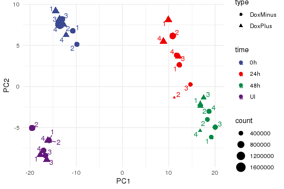

```r
ggpoints(df,modifyList(aes(PC1,PC2),myaes))
```

```r
set.seed(seed)
um <- uwot::umap(p$x,n_nei,2)
df <- as_tibble(um) %>% rename(UMAP1=V1,UMAP2=V2) %>% bind_cols(df)
```

```
The `x` argument of `as_tibble.matrix()` must have unique column names if `.name_repair` is omitted as of tibble 2.0.0.
Using compatibility `.name_repair`.
```

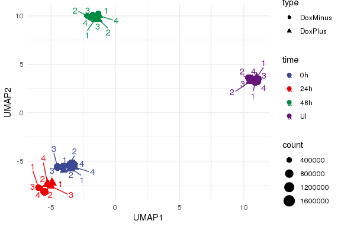

```r
ggpoints(df,modifyList(aes(UMAP1,UMAP2),myaes))
```

```r
print(df)
```

| UMAP1 | UMAP2 | sample0 | barcode | growth | sample | group | time | type | seq | rep | count | PC1 | PC2 | PC3 | PC4 | PC5 | PC6 | PC7 | PC8 | PC9 | PC10 | PC11 | PC12 | PC13 | PC14 | PC15 | PC16 | PC17 | PC18 | … |
| --- | --- | --- | --- | --- | --- | --- | --- | --- | --- | --- | --- | --- | --- | --- | --- | --- | --- | --- | --- | --- | --- | --- | --- | --- | --- | --- | --- | --- | --- | --- |
| 10.894890 | 3.113268 | Dox-_UI_1 | ATGCATATG | UI | BRB_UI_DoxMinus_1 | BRB_UI_DoxMinus | UI | DoxMinus | BRB | 1 | 699171 | -15.893826 | -6.5441567 | -2.7392642 | 0.07236122 | -1.32307782 | 0.92836550 | 0.6767937 | 4.3136841 | -4.68577952 | -1.38804045 | -1.05069719 | -1.9133907 | -0.704046173 | -2.69470579 | -0.83102204 | 0.5729134 | -3.6710279 | 1.4126079 | … |
| 10.405647 | 3.579801 | Dox-_UI_2 | ATTATGCAA | UI | BRB_UI_DoxMinus_2 | BRB_UI_DoxMinus | UI | DoxMinus | BRB | 2 | 871303 | -19.539909 | -5.0440518 | -2.2507800 | -1.54207282 | -0.63251845 | -0.04717445 | -1.9172595 | -0.1893282 | 3.20111443 | 0.45707432 | 2.95925750 | 0.6567654 | 0.158169768 | -0.48903468 | -1.26662554 | 4.6677266 | 3.1430387 | -3.7384635 | … |
| 11.137993 | 3.508895 | Dox-_UI_3 | ATCGGTTGC | UI | BRB_UI_DoxMinus_3 | BRB_UI_DoxMinus | UI | DoxMinus | BRB | 3 | 679935 | -16.637778 | -8.4064906 | -2.4960675 | 0.62027675 | -0.81360431 | -0.60277557 | 0.4767009 | 2.4967586 | 2.83676129 | -0.23585528 | 4.52123139 | 1.5564047 | -5.716280062 | -2.45872289 | 1.04427064 | -0.5820445 | 0.5365473 | -1.2575339 | … |
| 11.087178 | 3.218207 | Dox-_UI_4 | ACTGCGCGG | UI | BRB_UI_DoxMinus_4 | BRB_UI_DoxMinus | UI | DoxMinus | BRB | 4 | 721034 | -17.070737 | -7.7911616 | -3.7631364 | -0.87625970 | 2.95275012 | 0.27799790 | -0.6249330 | -3.3615105 | 2.48313724 | -0.60041816 | -1.34132954 | -1.8007512 | -0.546779191 | -3.10891134 | 0.45077114 | 1.7646884 | 1.9626723 | -2.7930580 | … |
| 10.993903 | 3.619896 | Dox+_UI_1 | AAGGAGAGT | UI | BRB_UI_DoxPlus_1 | BRB_UI_DoxPlus | UI | DoxPlus | BRB | 1 | 742420 | -17.752174 | -8.3240593 | -1.0002048 | 0.03689610 | 0.95366580 | -1.17799884 | 0.7031784 | 0.2817542 | 0.57249236 | 1.55339155 | -3.87756122 | -1.0659764 | 0.962436238 | 5.57178263 | -1.43273907 | 2.8524756 | -1.5142138 | 0.2628295 | … |
| 10.502797 | 3.254259 | Dox+_UI_2 | AGGAGAGAG | UI | BRB_UI_DoxPlus_2 | BRB_UI_DoxPlus | UI | DoxPlus | BRB | 2 | 636365 | -15.968829 | -6.6155540 | 1.4899238 | -0.14241061 | 0.90534778 | -1.18993592 | 0.9025543 | -3.1488976 | -0.27008272 | 2.03502131 | -1.99734748 | 2.0671744 | -0.383052642 | 1.04919304 | -1.70672565 | -2.3772663 | -1.9887835 | 2.1756021 | … |
| 10.663496 | 3.416200 | Dox+_UI_3 | CAGTCTAGA | UI | BRB_UI_DoxPlus_3 | BRB_UI_DoxPlus | UI | DoxPlus | BRB | 3 | 685029 | -16.369342 | -8.8982130 | -3.6285637 | -2.42151110 | -1.69735611 | 0.79655632 | -1.2214296 | -1.9044876 | -1.49581046 | 1.36641732 | -0.32118821 | 1.4213102 | 2.036647439 | 0.79243998 | 5.12525107 | -1.8299251 | -0.3159377 | 1.3200968 | … |
| 10.661604 | 3.487059 | Dox+_UI_4 | CAACGAGAT | UI | BRB_UI_DoxPlus_4 | BRB_UI_DoxPlus | UI | DoxPlus | BRB | 4 | 643096 | -16.178898 | -6.5802951 | 1.8374935 | -2.55606770 | -0.95924417 | 0.64095898 | 2.5122553 | 0.5571177 | -6.98950915 | -1.23001608 | 1.00937240 | -0.1433244 | 2.810531691 | 0.67029430 | -1.69011191 | -3.3503401 | 1.7177430 | 2.8747555 | … |
| -3.986181 | -5.522352 | Dox-_Diff0h_1 | CTCTATTAA | Diff0h | BRB_0h_DoxMinus_1 | BRB_0h_DoxMinus | 0h | DoxMinus | BRB | 1 | 706396 | -10.754033 | 6.7764489 | -0.8230746 | 2.89014424 | -0.33744840 | 0.32911375 | -0.5050229 | 2.9398034 | 1.41659711 | -3.49964743 | 0.04036880 | 3.2554100 | 1.309766950 | 1.19018947 | 0.39892254 | -5.2787304 | -1.4126607 | -7.4848326 | … |
| -3.556578 | -5.308415 | Dox-_Diff0h_2 | CTGATGACG | Diff0h | BRB_0h_DoxMinus_2 | BRB_0h_DoxMinus | 0h | DoxMinus | BRB | 2 | 599006 | -9.860234 | 5.1304108 | 5.1565341 | 1.88006439 | 2.41677405 | 3.30024939 | 2.6298226 | 5.2764038 | -0.47805107 | -3.73667131 | 1.19411906 | 0.7198120 | 3.403044336 | -5.61294166 | -2.63424444 | 2.6693781 | 1.0950093 | 3.3153406 | … |

[output cut: 22 more lines]

```r
##  kuwakado 変更 ##
ggpoints <- function(x,...)
  ggplot(x,...) + geom_point(stroke=1) + theme_minimal() + mycolor

#ggpoints(df,modifyList(aes(PC1,PC2),myaes2))
#set.seed(seed)
#um <- uwot::umap(p$x,n_nei,2)
#df <- as_tibble(um) %>% rename(UMAP1=V1,UMAP2=V2) %>% bind_cols(df)
#ggpoints(df,modifyList(aes(UMAP1,UMAP2),myaes2))
## ## ## ##
```

### DESeq2

#### Fit model

```r
dds <- DESeq2::DESeqDataSetFromMatrix(X[,label$sample],label,model)
dds <- DESeq2::DESeq(dds)
```

```
-- note: fitType='parametric', but the dispersion trend was not well captured by the
   function: y = a/x + b, and a local regression fit was automatically substituted.
   specify fitType='local' or 'mean' to avoid this message next time.
```

```r
#=====#

dds <- DESeq2::estimateSizeFactors(dds)
norm <- DESeq2::counts(dds,normalized=TRUE) #DEGを取った後のクラスタリングに使う。

normalizedcount <- as.data.frame(norm) %>% tibble::rownames_to_column("ens_gene") %>% as_tibble
readr::write_csv(normalizedcount, "./H3mm18KO_3T3_Dox_normCount.csv")

normalizedcount %>% inner_join(e2g, by = "ens_gene")  %>% dplyr::select("ens_gene","ext_gene", "biotype","chr", all_of(label$sample)) %>% readr::write_csv("./H3mm18KO_3T3_Dox_normCount_genename.csv")

#count_dds <- estimateSizeFactors(dds)
#counts(count_dds, normalized=TRUE)

####--- + size factors を書き出し ------------------####
as.data.frame(DESeq2::sizeFactors(dds))  %>% tibble::rownames_to_column("sample") %>% readr::write_csv("./H3mm18KO_3T3_Dox__sizefactors.csv")
sizefactors_sample <- as.data.frame(DESeq2::sizeFactors(dds))  %>% tibble::rownames_to_column("sample")

sizefactors_sample
```

| sample | DESeq2::sizeFactors(dds) |
| --- | --- |
| BRB_UI_DoxMinus_1 | 1.1668045 |
| BRB_UI_DoxMinus_2 | 1.4973373 |
| BRB_UI_DoxMinus_3 | 1.1390907 |
| BRB_UI_DoxMinus_4 | 1.2049140 |
| BRB_UI_DoxPlus_1 | 1.2503467 |
| BRB_UI_DoxPlus_2 | 1.0754587 |
| BRB_UI_DoxPlus_3 | 1.1528272 |
| BRB_UI_DoxPlus_4 | 1.0933594 |
| BRB_0h_DoxMinus_1 | 1.1558330 |
| BRB_0h_DoxMinus_2 | 0.9715016 |

[output cut: 22 more lines]

```r
NA
```

vst => z score

```r
vsd <- DESeq2::vst(dds) #normalized countが入っている。(vstかrlog)
Xd <- SummarizedExperiment::assay(vsd) # 全て選択(200326) 20190920を元に (191024)
Xs <- Xd %>% t %>% scale %>% t

vst_score <- Xd %>% as.data.frame() %>% tibble::rownames_to_column("ens_gene") %>% as_tibble #200909 add
vst_type <- vst_score  %>% annotate %>% dplyr::select("ens_gene","ext_gene", "biotype","chr", all_of(label$sample))


zscore <- Xs %>% as.data.frame() %>% tibble::rownames_to_column("ens_gene") %>% as_tibble
zscore_type <- zscore  %>% annotate %>% dplyr::select("ens_gene","ext_gene", "biotype","chr", all_of(label$sample))

readr::write_csv(vst_score, "H3mm18KO_3T3_Dox__vst_all.csv") #200909 add
readr::write_csv(vst_type, "H3mm18KO_3T3_Dox__vst_type_all.csv") #200909 add
readr::write_csv(zscore, "H3mm18KO_3T3_Dox__zscore_all.csv")
readr::write_csv(zscore_type, "H3mm18KO_3T3_Dox__zscore_type_all.csv")

nrow(vst_type)
```

```
[1] 21707
```

```r
nrow(zscore_type)
```

```
[1] 21707
```

#### Diagnostics plot

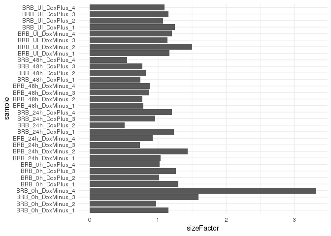

```r
DESeq2::sizeFactors(dds) %>%
  {tibble(sample=names(.),sizeFactor=.)} %>%
  ggplot(aes(sample,sizeFactor)) + theme_minimal() +
  geom_bar(stat="identity") + coord_flip()
```

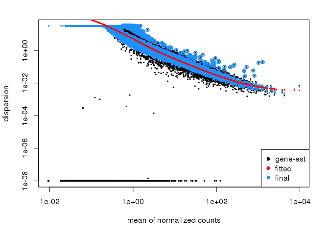

```r
DESeq2::plotDispEsts(dds)
```

ここから 20200909 add

### Dimension reduction (VST)

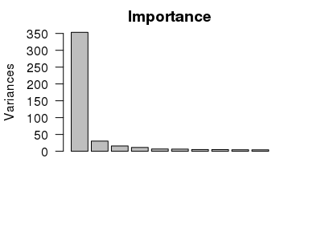

```r
# set scale=TRUE if the patterns (not level) is the matter
## Xd: vst values

p_vst <- prcomp(t(Xd[rank(-apply(Xd,1,var)) <= ntop,]),scale=scalerows,center=TRUE) ## ここでは、zscoreを使ってPCAを行なっているのと同じ。
screeplot(p_vst,las=2,main="Importance")
```

```r
print(summary(p_vst)$imp[,seq(min(10,ncol(X)))])
```

```
                            PC1      PC2      PC3      PC4      PC5      PC6      PC7      PC8      PC9     PC10
Standard deviation     18.79665 5.505437 3.983509 3.377313 2.607703 2.534019 2.287497 2.249356 2.109107 2.099308
Proportion of Variance  0.70663 0.060620 0.031740 0.022810 0.013600 0.012840 0.010470 0.010120 0.008900 0.008810
Cumulative Proportion   0.70663 0.767250 0.798980 0.821800 0.835400 0.848240 0.858710 0.868820 0.877720 0.886540
```

```r
## save data

var_vst_all <- apply(Xd,1,var) %>% as.data.frame()  %>% tibble::rownames_to_column("ens_gene") %>% as_tibble %>% dplyr::rename(var=".")
var_vst_all %>% readr::write_csv("./PCA/var_vst_all.csv")
var_vst_all %>% nrow()
```

```
[1] 21707
```

```r
rankvar_vst_all <- rank(-apply(Xd,1,var)) %>% as.data.frame()  %>% tibble::rownames_to_column("ens_gene") %>% as_tibble  %>%  dplyr::rename(ranking_var=".")
rankvar_vst_all %>% readr::write_csv("./PCA/rankvar_vst_all.csv")
rankvar_vst_all %>% nrow()
```

```
[1] 21707
```

```r
vst__rankvartop500gene <- Xd[rank(-apply(Xd,1,var)) <= ntop,] %>% as.data.frame()  %>% tibble::rownames_to_column("ens_gene") %>% as_tibble
vst__rankvartop500gene %>% readr::write_csv("./PCA/H3mm18KO_3T3_Dox__vst__rankvartop500gene.csv")
vst__rankvartop500gene %>% nrow()
```

```
[1] 500
```

```r
p_vst_scale <- p_vst$scale %>% as.data.frame() %>% tibble::rownames_to_column("ens_gene") %>% as_tibble
p_vst_sdev <- p_vst$sdev %>% as.data.frame() %>% tibble::rownames_to_column("PC") %>% as_tibble  %>%  dplyr::rename(Standard_deviation=".")
p_vst_x <- p_vst$x %>% as.data.frame()  %>% tibble::rownames_to_column("sample") %>% as_tibble
p_vst_center <- p_vst$center %>% as.data.frame() %>% tibble::rownames_to_column("ens_gene") %>% as_tibble
p_vst_rotation <- p_vst$rotation %>% as.data.frame() %>% tibble::rownames_to_column("ens_gene") %>% as_tibble

p_vst_scale %>% readr::write_csv("./PCA/H3mm18KO_3T3_Dox__vartop500gene__pca_vst_scale.csv")
p_vst_sdev %>% readr::write_csv("./PCA/H3mm18KO_3T3_Dox__vartop500gene__pca_vst_sdev.csv")
p_vst_x %>% readr::write_csv("./PCA/H3mm18KO_3T3_Dox__vartop500gene__vst__pca_vst_x.csv")
p_vst_center %>% readr::write_csv("./PCA/H3mm18KO_3T3_Dox__vartop500gene__vst__pca_vst_center.csv")
p_vst_rotation %>% readr::write_csv("./PCA/H3mm18KO_3T3_Dox__vartop500gene__vst__pca_vst_rotation.csv")
```

```r
#label <- def %>% filter(sample %in% colnames(X))
df_vst <- data.frame(p_vst$x) %>% as_tibble(rownames="sample") %>%
  inner_join(label,.) %>% select(-file)
df_vst <- df_vst  %>% mutate(time=factor(time, c("UI", "0h","24h","48h"))) %>% mutate(type=factor(type,c("DoxPlus","DoxMinus"))) %>% mutate(rep=factor(rep, c("1", "2", "3", "4"))) %>% mutate(group=factor(group, c("BRB_UI_DoxMinus", "BRB_UI_DoxPlus", "BRB_0h_DoxMinus","BRB_0h_DoxPlus","BRB_24h_DoxMinus","BRB_24h_DoxPlus","BRB_48h_DoxMinus","BRB_48h_DoxPlus"))) # 20200908
print(df_vst)
```

| sample0 | barcode | growth | sample | group | time | type | seq | rep | count | PC1 | PC2 | PC3 | PC4 | PC5 | PC6 | PC7 | PC8 | PC9 | PC10 | PC11 | PC12 | PC13 | PC14 | PC15 | PC16 | PC17 | PC18 | PC19 | PC20 | … |
| --- | --- | --- | --- | --- | --- | --- | --- | --- | --- | --- | --- | --- | --- | --- | --- | --- | --- | --- | --- | --- | --- | --- | --- | --- | --- | --- | --- | --- | --- | --- |
| Dox-_UI_1 | ATGCATATG | UI | BRB_UI_DoxMinus_1 | BRB_UI_DoxMinus | UI | DoxMinus | BRB | 1 | 699171 | -20.41930 | -6.777521 | -2.256299 | 1.06720405 | -0.03558929 | 0.5373987 | -0.25898300 | 2.22976338 | -1.84697600 | 1.11409400 | 0.40328145 | 0.3311564 | 2.27871405 | 1.0981967 | -3.99208975 | -1.37770930 | -0.3150808 | -0.06896727 | 2.778880015 | 1.0817067 | … |
| Dox-_UI_2 | ATTATGCAA | UI | BRB_UI_DoxMinus_2 | BRB_UI_DoxMinus | UI | DoxMinus | BRB | 2 | 871303 | -21.03149 | -6.140102 | -1.656012 | 2.72011923 | -0.06491012 | 0.4434227 | 0.78558295 | -0.86499137 | -1.03233079 | -2.46722518 | -0.65498273 | 0.4180931 | 1.33882836 | -1.6001133 | 2.03560175 | 1.80365684 | 1.0402808 | 1.17942231 | -2.979931446 | 1.4756354 | … |
| Dox-_UI_3 | ATCGGTTGC | UI | BRB_UI_DoxMinus_3 | BRB_UI_DoxMinus | UI | DoxMinus | BRB | 3 | 679935 | -20.67752 | -6.485123 | -1.665806 | 2.35988904 | 0.61949335 | 1.7026561 | 1.36083488 | 1.71409584 | 1.25408063 | -0.54209665 | -2.03033225 | -1.6810058 | -1.97121422 | -0.1779031 | -1.12445387 | -0.73260502 | 1.0592242 | -3.80089092 | 0.455283081 | -3.3065415 | … |
| Dox-_UI_4 | ACTGCGCGG | UI | BRB_UI_DoxMinus_4 | BRB_UI_DoxMinus | UI | DoxMinus | BRB | 4 | 721034 | -20.74942 | -6.580608 | -1.584806 | 0.60290133 | 0.95753987 | 0.6210485 | 0.51824713 | 1.12364969 | -1.12836558 | 0.84207712 | -0.03464566 | -0.6666830 | 0.04499674 | -0.4292242 | 1.86151973 | -0.83737999 | 0.6855789 | -0.19703035 | 0.818530672 | -0.5173733 | … |
| Dox+_UI_1 | AAGGAGAGT | UI | BRB_UI_DoxPlus_1 | BRB_UI_DoxPlus | UI | DoxPlus | BRB | 1 | 742420 | -21.63488 | -6.774012 | -1.555867 | -0.26925599 | 0.45807141 | 0.0510949 | -0.97087705 | 0.05589985 | 2.51321035 | 0.25802706 | 0.80903346 | 0.2657679 | -1.72797054 | 0.6810190 | 0.84585445 | 0.17992763 | 0.5414547 | -1.91274148 | 0.005264449 | 1.1430966 | … |
| Dox+_UI_2 | AGGAGAGAG | UI | BRB_UI_DoxPlus_2 | BRB_UI_DoxPlus | UI | DoxPlus | BRB | 2 | 636365 | -21.41233 | -6.273078 | -2.069122 | -0.48900983 | -0.93353894 | -0.5745771 | -0.03236583 | -2.27132995 | 0.37611731 | -0.89864372 | -1.32703847 | -1.4298021 | 0.28374316 | -1.5307468 | 1.37603143 | 0.90692634 | 2.1500929 | 1.33849731 | 0.513340172 | -0.6042660 | … |
| Dox+_UI_3 | CAGTCTAGA | UI | BRB_UI_DoxPlus_3 | BRB_UI_DoxPlus | UI | DoxPlus | BRB | 3 | 685029 | -22.00361 | -6.807894 | -1.803369 | -0.83376998 | -1.15010530 | -2.3366060 | -0.17139456 | -1.02029497 | -0.69248191 | 0.54535527 | 0.19895254 | 1.7090864 | -0.59488001 | 0.6723728 | -0.02128492 | 0.85274814 | -3.3689602 | -0.92128350 | -0.255223981 | -1.6047223 | … |
| Dox+_UI_4 | CAACGAGAT | UI | BRB_UI_DoxPlus_4 | BRB_UI_DoxPlus | UI | DoxPlus | BRB | 4 | 643096 | -20.76736 | -6.574507 | -1.907257 | -1.97185334 | 0.31958851 | -0.7110451 | -0.46463947 | -0.86839440 | -0.09558568 | 1.16456056 | 2.48013061 | 0.8438372 | 0.57546409 | 1.1366412 | -1.37000212 | -0.20143815 | -1.5725887 | 4.17774549 | -1.169355950 | 2.7039958 | … |
| Dox-_Diff0h_1 | CTCTATTAA | Diff0h | BRB_0h_DoxMinus_1 | BRB_0h_DoxMinus | 0h | DoxMinus | BRB | 1 | 706396 | -13.34334 | 6.934582 | 2.996120 | 1.07395616 | 0.76233822 | 1.5419178 | 2.00059269 | 4.07741166 | -2.52292399 | -0.47633529 | 0.24200354 | -1.9855844 | 0.47435217 | 3.8187466 | -0.36088932 | -0.18220935 | -2.2965667 | 0.16287726 | -3.626063251 | 1.1800787 | … |
| Dox-_Diff0h_2 | CTGATGACG | Diff0h | BRB_0h_DoxMinus_2 | BRB_0h_DoxMinus | 0h | DoxMinus | BRB | 2 | 599006 | -13.80094 | 7.166423 | 3.994800 | 1.08429432 | -1.14898219 | 1.0752199 | 0.20058319 | 3.14080622 | 0.39785760 | 2.20337225 | -1.93407712 | -0.8553303 | -2.10368057 | 1.8294217 | -1.72472053 | 1.40802365 | 5.2501198 | 0.55129224 | 0.831243937 | 1.6673302 | … |

[output cut: 22 more lines]

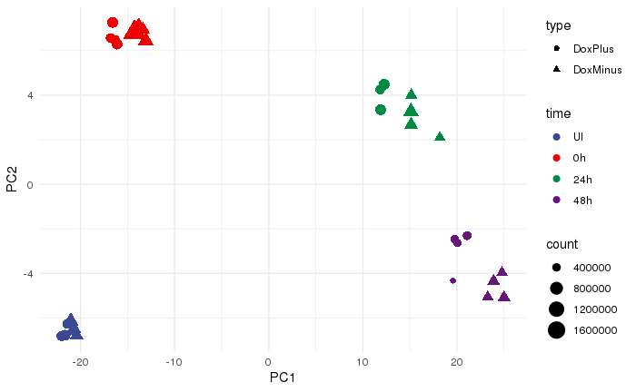

```r
df_vst %>% readr::write_csv("./PCA/PCA_vst_vartop500gene.csv")
ggpoints(df_vst,modifyList(aes(PC1,PC2),myaes))
```

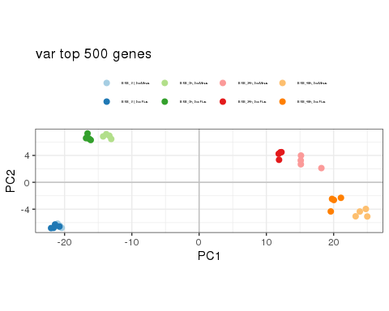

```r
cols_pca <- brewer.pal(8, "Paired")

mmplot <- df_vst %>% ggplot(aes(x=PC1,y=PC2,color=group)) + geom_abline(intercept=0,slope=0,colour="gray") + geom_vline(xintercept=0,colour="gray") + geom_point(stroke=1) + theme_bw() +  scale_color_manual(values = cols_pca) + ggtitle("var top 500 genes")  + theme(legend.position = "top",legend.text = element_text(size=3),legend.title = element_blank()) + coord_fixed(ratio=1)

mmplot
```

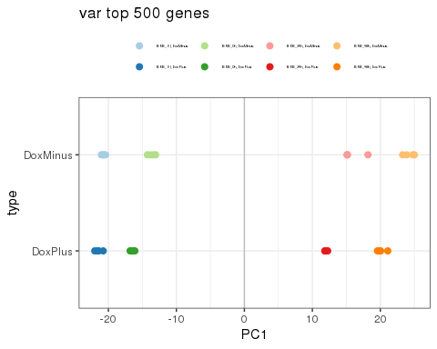

```r
ggsave(plot = mmplot,file="./PCA/PC1PC2_vst_vartop500gene.pdf", dpi = 100, width = 4, height = 5)


mmplot <- df_vst %>% ggplot(aes(x=PC1,y=type,color=group)) + geom_vline(xintercept=0,colour="gray") + geom_point(stroke=1) + theme_bw() +  scale_color_manual(values = cols_pca) + ggtitle("var top 500 genes")   + theme(legend.position = "top",legend.text = element_text(size=3),legend.title = element_blank())

mmplot
```

```r
ggsave(plot = mmplot,file="./PCA/PC1_vst_vartop500gene.pdf", dpi = 100, width = 4, height = 2)
```

### Check (vs 20200811 data)

PC1_groupavg <- df_vst %>% group_by(group) %>% summarise(PC1_avg = mean(PC1),PC1_sd=sd(PC1),PC1_V=sd(PC1)*sd(PC1), PC1_S=sd(PC1)*sd(PC1)*(4-1))

#PC1_group2 <- PC1_group %>% dplyr::select(sample, group,time,type,seq,rep,PC1,PC1_avg,PC1_sd) %>% group_by(group,sample,time,type) %>% summarise(PC1,PC1_avg,PC1_sd, #PC1_d=PC1-PC1_avg,PC1_d2=(PC1-PC1_avg)*(PC1-PC1_avg)) %>% ungroup() #PC1_group2 %>% group_by(group,time,type) %>% summarise(PC1_S=sum(PC1_d2)) %>% ungroup()

```r
PC1_Sw <- df_vst %>% group_by(group,time,type) %>% summarise(PC1_avg = mean(PC1),PC1_sd=sd(PC1),PC1_V=sd(PC1)*sd(PC1), PC1_Sk2=sd(PC1)*sd(PC1)*(4-1)) %>% ungroup()
#PC1_Sw %>% dplyr::select(group,PC1_avg) %>% spread(key=group,value=PC1_avg)
#PC1_Sw_UI <- PC1_Sw %>% filter(time=="UI")

Time_list <- c("UI","0h","24h","48h")


#######
print("~~ H3p3_BRB ~~")
```

```
[1] "~~ H3p3_BRB ~~"
```

```r
for (i in 1:length(Time_list)) {
  print(paste("-----",Time_list[i], "--- H3p3clusterAll: H3p3_BRB --"))
  sb1 <- PC1_Sw %>% filter((time==Time_list[i]))
  sb2 <- (sb1$PC1_avg[1]-sb1$PC1_avg[2])^2
  sw1 <- sum(sb1$PC1_Sk2[1]+sb1$PC1_Sk2[2])
  print(sb2)

  if (i == 1) {
    sb_r <- data.frame(time=Time_list[i],group1=sb1$group[1],group2=sb1$group[2],type1=sb1$type[1],type2=sb1$type[2],PC1_Sb=sb2,PC1_Sw=sw1)%>% as_tibble()
  }
  else {
    sb_3 <- data.frame(time=Time_list[i],group1=sb1$group[1],group2=sb1$group[2],type1=sb1$type[1],type2=sb1$type[2],PC1_Sb=sb2,PC1_Sw=sw1)%>% as_tibble()
    sb_r <- bind_rows(sb_r, sb_3)
  }
}
```

```
[1] "----- UI --- H3p3clusterAll: H3p3_BRB --"
[1] 0.540389
[1] "----- 0h --- H3p3clusterAll: H3p3_BRB --"
[1] 8.099082
[1] "----- 24h --- H3p3clusterAll: H3p3_BRB --"
[1] 15.0253
[1] "----- 48h --- H3p3clusterAll: H3p3_BRB --"
[1] 17.00153
```

```r
PC1_Sb <- sb_r

print(PC1_Sb)
```

| time | group1 | group2 | type1 | type2 | PC1_Sb | PC1_Sw |
| --- | --- | --- | --- | --- | --- | --- |
| UI | BRB_UI_DoxMinus | BRB_UI_DoxPlus | DoxMinus | DoxPlus | 0.540389 | 0.998117 |
| 0h | BRB_0h_DoxMinus | BRB_0h_DoxPlus | DoxMinus | DoxPlus | 8.099082 | 1.105266 |
| 24h | BRB_24h_DoxMinus | BRB_24h_DoxPlus | DoxMinus | DoxPlus | 15.025302 | 7.089377 |
| 48h | BRB_48h_DoxMinus | BRB_48h_DoxPlus | DoxMinus | DoxPlus | 17.001531 | 3.309150 |

```r
PC1_SwSb <- left_join(PC1_Sw,PC1_Sb) %>% mutate(PC1_Jw=PC1_Sb/PC1_Sw)
print(PC1_SwSb)
```

| group | time | type | PC1_avg | PC1_sd | PC1_V | PC1_Sk2 | group1 | group2 | type1 | type2 | PC1_Sb | PC1_Sw | PC1_Jw |
| --- | --- | --- | --- | --- | --- | --- | --- | --- | --- | --- | --- | --- | --- |
| BRB_UI_DoxMinus | UI | DoxMinus | -20.71943 | 0.2517393 | 0.06337269 | 0.1901181 | BRB_UI_DoxMinus | BRB_UI_DoxPlus | DoxMinus | DoxPlus | 0.540389 | 0.998117 | 0.5414085 |
| BRB_UI_DoxPlus | UI | DoxPlus | -21.45454 | 0.5189730 | 0.26933299 | 0.8079990 | BRB_UI_DoxMinus | BRB_UI_DoxPlus | DoxMinus | DoxPlus | 0.540389 | 0.998117 | 0.5414085 |
| BRB_0h_DoxMinus | 0h | DoxMinus | -13.61850 | 0.5275090 | 0.27826570 | 0.8347971 | BRB_0h_DoxMinus | BRB_0h_DoxPlus | DoxMinus | DoxPlus | 8.099082 | 1.105266 | 7.3277247 |
| BRB_0h_DoxPlus | 0h | DoxPlus | -16.46439 | 0.3002602 | 0.09015616 | 0.2704685 | BRB_0h_DoxMinus | BRB_0h_DoxPlus | DoxMinus | DoxPlus | 8.099082 | 1.105266 | 7.3277247 |
| BRB_24h_DoxMinus | 24h | DoxMinus | 15.88987 | 1.5253440 | 2.32667436 | 6.9800231 | BRB_24h_DoxMinus | BRB_24h_DoxPlus | DoxMinus | DoxPlus | 15.025302 | 7.089377 | 2.1194109 |
| BRB_24h_DoxPlus | 24h | DoxPlus | 12.01362 | 0.1909219 | 0.03645119 | 0.1093536 | BRB_24h_DoxMinus | BRB_24h_DoxPlus | DoxMinus | DoxPlus | 15.025302 | 7.089377 | 2.1194109 |
| BRB_48h_DoxMinus | 48h | DoxMinus | 24.23834 | 0.8042691 | 0.64684874 | 1.9405462 | BRB_48h_DoxMinus | BRB_48h_DoxPlus | DoxMinus | DoxPlus | 17.001531 | 3.309150 | 5.1377343 |
| BRB_48h_DoxPlus | 48h | DoxPlus | 20.11505 | 0.6754266 | 0.45620112 | 1.3686034 | BRB_48h_DoxMinus | BRB_48h_DoxPlus | DoxMinus | DoxPlus | 17.001531 | 3.309150 | 5.1377343 |

```r
NA
```

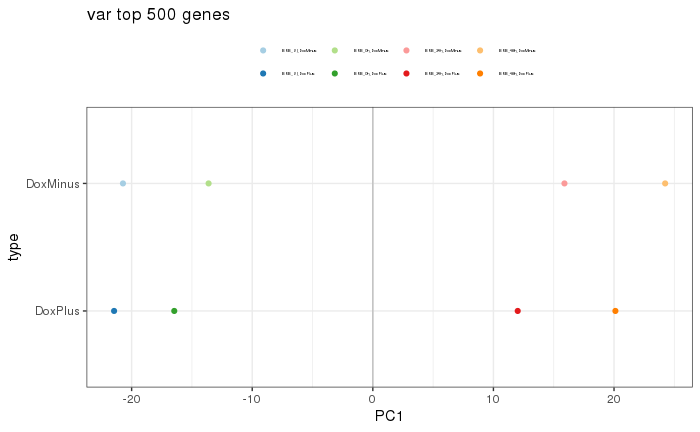

```r
mmplot <- df_vst %>% ggplot(aes(x=PC1,y=type,color=group)) + geom_vline(xintercept=0,colour="gray")+ theme_bw() +  scale_color_manual(values = cols_pca) + ggtitle("var top 500 genes")   + theme(legend.position = "top",legend.text = element_text(size=3),legend.title = element_blank())+ geom_point(aes(x=PC1_avg,y=type),data=PC1_SwSb)

mmplot
ggsave(plot = mmplot,file="./PCA/PC1_vst_vartop500gene__with_Jw.pdf", dpi = 100, width = 4, height = 2)
```

```r
NA
NA
```